# **Kỹ thuật lập trình Python**

## **Làm quen với Numpy**

### **Bài 1. Tính toán trên dãy số**

#### **1. Tạo một dãy số a có N phần tử (N = 10)**

```python
import numpy as np # Khai báo thư viện numpy

print("1. Tạo một dãy số a có N phần tử (N = 10)")
a = np.random.randint(100, 200, size=10)
# ...

print("Day so a: ", a)
```

```
1. Tạo một dãy số a có N phần tử (N = 10)
Day so a:  [161 122 106 159 112 175 178 193 139 152]
```

#### **2. Các thao tác trên dãy số a**

**(a)** Bình phương các phần tử trong dãy số  
**(b)** Tìm số lượng các phần tử của dãy số  
**(c)** In ra giá trị lớn nhất, giá trị nhỏ nhất và giá trị trung bình  
**(d)** Tính phương sai của dãy số: $\sigma^2 = \frac{\sum (a_i - \mu)^2}{N - 1}$ với $\mu = \frac{\sum a_i}{N}$ và độ lệch chuẩn $var = \sqrt{\sigma^2}$

```python
print("2. Các thao tác tính toán đơn giản với dãy số a")
a = np.array([120, 183, 160, 175, 145, 162, 190, 160, 152, 162,])
# ...
a2 = a**2
print("a. Binh phuong a: ", a2)

na = a.size
print("\nb. Do dai a: ", na)

v_min = np.min(a)
v_max = np.max(a)
v_avg = np.average(a)
# ...

print(f'\nc. Gia tri lon nhat: [{v_max}], gia tri nho nhat: [{v_min}], gia tri trung binh [{v_avg}]')

v_sigma2 = np.var(a, ddof=1)
v_var = np.std(a, ddof=1)
# ...

print(f'\nd. Phuong sai: [{v_sigma2: .2f}] va do lech chuan: [{v_var: .2f}]')
```

```
2. Các thao tác tính toán đơn giản với dãy số a
a. Binh phuong a:  [14400 33489 25600 30625 21025 26244 36100 25600 23104 26244]

b. Do dai a:  10

c. Gia tri lon nhat: [190], gia tri nho nhat: [120], gia tri trung binh [160.9]

d. Phuong sai: [ 393.66] va do lech chuan: [ 19.84]
```

#### **3. Toán tử trên hai dãy số**

**(a)** Tạo dãy số x có 10 phần tử từ 1 đến 10 (dùng hàm *np.arange*)  
**(b)** Liệt kê và đếm số lượng phần tử chẵn và lẻ có trong dãy a và x  
**(c)** Tính khoảng cách giữa các phần tử ở vị trí lẻ của mảng a và x với $ s = \sqrt{\sum{(a_i - x_i)^2}}$ với $i$ lẻ  
**(d)** Tìm khoảng cách nhỏ nhất giữa tập a và x. Ví dụ:$ min $ {{1, 3, 5}, {2, 10, 8}} = 1

```python
print("3. Xử lý khác trên dãy số")
x = np.arange(1, 11)
# ...

print(f'a. Day so x: {x}')
```

```
3. Xử lý khác trên dãy số
a. Day so x: [ 1  2  3  4  5  6  7  8  9 10]
```

```python
def loc_chan(a):
    return a % 2 == 0

def dem(a):
    return a[a % 2 == 0], len(a[a % 2 == 0])

a = np.array([120, 183, 160, 175, 145, 162, 190, 160, 152, 162])
a_la_chan = loc_chan(a)
a_chan, n_a_chan = dem(a)

x_la_chan = loc_chan(x)
x_chan, n_x_chan = dem(x)
# ...

print( "b. Cac phan tu chan trong day a, b: ")
print(f"+ Day a: {a}")
print(f"  - Loc chan: {a_la_chan}")
print(f"  - Day chua phan tu chan trong a: {a_chan}, so luong {n_a_chan} phan tu.")
print(f"+ Day x: {x}")
print(f"  - Loc chan: {x_la_chan}")
print(f"  - Day chua phan tu chan trong a: {x_chan}, so luong {n_x_chan} phan tu.")
```

```
b. Cac phan tu chan trong day a, b:
+ Day a: [120 183 160 175 145 162 190 160 152 162]
  - Loc chan: [ True False  True False False  True  True  True  True  True]
  - Day chua phan tu chan trong a: [120 160 162 190 160 152 162], so luong 7 phan tu.
+ Day x: [ 1  2  3  4  5  6  7  8  9 10]
  - Loc chan: [False  True False  True False  True False  True False  True]
  - Day chua phan tu chan trong a: [ 2  4  6  8 10], so luong 5 phan tu.
```

```python
v_le = np.arange(1, len(a), 2)

a_le = a[v_le]
x_le = x[v_le]

hieu_le = a_le - x_le

kc_le = np.linalg.norm(hieu_le)
# ...

print( "c.Tính hiệu các phần tử ở vị trí lẻ của mảng a và x: ")
print(f"+ Vi tri le trong a va x: {v_le}")
print(f"+ Day so a: {a} va cac so o vi tri le: {a_le}")
print(f"+ Day so x: {x} va cac so o vi tri le: {x_le}")
print(f"+ Hieu cua a va x o vi tri le: {hieu_le}")
print(f"+ Khoang cach cac phan tu cua a va x o vi tri le: {kc_le: .2f}")
```

[output not shown]

```python
print("d. Tìm khoảng cách nhỏ nhất giữa tập a và x. Ví dụ: min({1, 3, 5}, {2, 10, 8}} = 1")
"""
Gợi ý: Áp dụng toán tử broatcasting
[[1],                    [[1, 1, 1],        [[2, 10, 8],    =   [[-1, -9, -7],
 [3],   - [2, 10, 8] =    [3, 3, 3],   -     [2, 10, 8],         [ 1, -7, -5],  --> np.min(np.abs(...)) = 1
 [5]]                     [5, 5, 5]]         [2, 10, 8]]         [ 3, -5, -3]]
"""
a = np.array([120, 183, 160, 175, 145, 162, 190, 160, 152, 162])
x = np.arange(1, 11)
v_min = np.min(np.abs(a[:, np.newaxis] - x))
# Tăng số chiều dùng tại vị trí chiều cuối dùng np.newaxis như sau: a[:, np.newaxis]
# ...

print(f"+ Day a: {a}")
print(f"+ Day x: {x}")
print(f"+ Khoang cach nho nhat: {v_min}")
```

```
d. Tìm khoảng cách nhỏ nhất giữa tập a và x. Ví dụ: min({1, 3, 5}, {2, 10, 8}} = 1
+ Day a: [120 183 160 175 145 162 190 160 152 162]
+ Day x: [ 1  2  3  4  5  6  7  8  9 10]
+ Khoang cach nho nhat: 110
```

#### **4. Sinh ngẫu nhiên dãy số**

```
a. Sinh ngẫu nhiên theo phân bố đều
+ Gia tri: [ 1  2  3  4  5  6  7  8  9 10]
+ So lan xuat hien: [1019  979  989 1033  956  993  991 1002 1029 1009]
+ Do thi ham so xuat hien
```

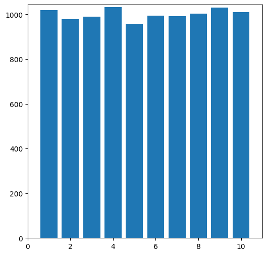

```python
import matplotlib.pyplot as plt  # Khai báo thư viện pyplot trong matplotlib
import numpy as np
# Sử dụng hàm np.random.randint để sinh dãy số ngẫu nhiên
# Sử dụng hàm np.unique để trả về tần số xuất hiện
# ...

a = np.random.randint(1, 11, 10000)
value, cnt = np.unique(a, return_counts=True)

print("a. Sinh ngẫu nhiên theo phân bố đều")
print(f"+ Gia tri: {value}")
print(f"+ So lan xuat hien: {cnt}")
print("+ Do thi ham so xuat hien")
plt.figure(figsize=(6,6))      #  kich thuoc ban ve
plt.bar(value, cnt)            #  ve cac khoi chu nhat theo day x, y
plt.xlim(0, 11)                #  gioi han truc x
plt.ylim(0, np.max(cnt) + 10)  #  gioi han truc y
plt.savefig("4a.png")          #  luu do thi
plt.show()                     #  hien thi do thi
```

```
b. Sinh cặp (x, y) với y làm hàm phân phối chuẩn
+ x: -5 <= min [-4.99] <= max [ 4.94] <= 5
+ Ve ham so y(x)
```

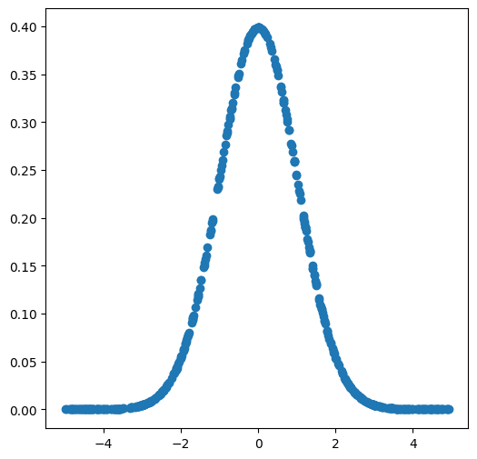

```python
# Sử dụm hàm np.random.rand() sinh số ngẫu nhiên trong [0,1) --> [0,1) * (b - a) + a --> [a, b)
# Sử dụng hàm sau để tính hàm xác suất chuẩn N(m, s): np.sqrt, np.exp
# ...
x_min, x_max = -5, 5   # khoảng sinh ngẫu nhiên
m, s = 0, 1            # trung bình và độ lệch chuẩn
N = 500                # số điểm sinh

# Sinh x trong [x_min, x_max]
x = np.random.rand(N) * (x_max - x_min) + x_min

# Hàm mật độ phân phối chuẩn N(m, s^2)
y = (1 / (np.sqrt(2 * np.pi * s**2))) * np.exp(-((x - m) ** 2) / (2 * s**2))

print("b. Sinh cặp (x, y) với y làm hàm phân phối chuẩn")
print(f"+ x: {x_min} <= min [{np.min(x): .2f}] <= max [{np.max(x): .2f}] <= {x_max}")
print(f"+ Ve ham so y(x)")
plt.figure(figsize=(6,6))      # kich thuoc ban ve
plt.scatter(x, y)              # ve cac diem (xi, yi)
plt.savefig("4b.png")          #  luu do thi
plt.show()                     #  hien thi do thi
```

```
c. Sinh day so theo phan phoi chuan
+ x: len = 100000, min [-3.163518868139164], max [5.314590945342333]
+ Mat so xac suat cua day so x
```

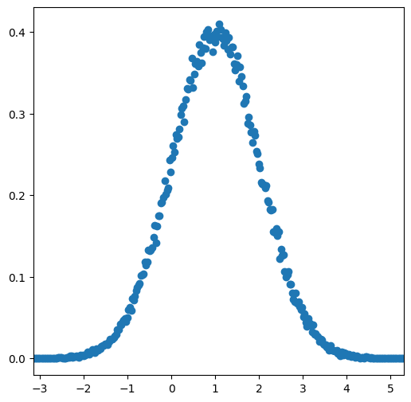

```python
# Sử dụng hàm np.random.randn() sinh phân phối chuẩn N(0,1) --> N(m,s^2) = m + N(0,1) * s
# Sử dụng hàm np.histogram với density=True để thống kê số lần xuất hiện với số bins = 300 (do dãy số thực)
# ...

# Tham số
m, s = 1, 1.0
N = 100000

# Sinh dãy số ngẫu nhiên theo N(m, s^2)
x = m + np.random.randn(N) * s

# Thống kê tần suất xuất hiện (histogram)
cnt, val = np.histogram(x, bins=300, density=True)

# Trục hoành là giá trị trung điểm của từng bin
val = (val[:-1] + val[1:]) / 2

print( "c. Sinh day so theo phan phoi chuan")
print(f"+ x: len = {len(x)}, min [{np.min(x)}], max [{np.max(x)}]")
print(f"+ Mat so xac suat cua day so x")
plt.figure(figsize=(6,6))      # kich thuoc ban ve
plt.xlim(np.min(val), np.max(val))
plt.scatter(val, cnt)
plt.show()
```

### **Bài 2. Tính toán trên ma trận**

#### **1. Tạo ma trận a có M = 6 dòng, N = 4 cột**

```python
a = np.random.randint(100, 200, (6, 4))

print("Ma trận a: \n", a)
```

```
Ma trận a:
 [[134 105 104 100]
 [118 111 110 172]
 [142 107 186 190]
 [144 122 142 118]
 [138 177 114 177]
 [117 199 147 112]]
```

#### **2. Các thao tác trên ma trận a**

**(a)** In ra ma trận chuyển vị  
**(b)** In ra phần tử ở vị trí dòng 2 cột 3  
**(c)** Trích xuất dòng đầu, dòng cuối, dòng 2  
**(d)** Trích xuất cột kế cuối, cột đầu  
**(e)** Đảo các giá trị trên từng cột  
**(f)** Tính tổng các dòng, trung bình các cột

```python
a = np.random.randint(1, 21, (4, 5))
print(a)

a_t = a.T
print(f"a. In ra ma trận chuyển vị: \n{a_t}")

v_23 = a[1, 2]
print(f"\nb. In ra phần tử ở vị trí dòng 2 cột 3: {v_23}")
d_0 = a[0]
d_last = a[-1]
d_2 = a[1]
print(f"\nc. Trích xuất các dòng: ")
print(f"   + Dòng đầu : {d_0}")
print(f"   + Dòng cuối: {d_last}")
print(f"   + Dòng hai : {d_2}")

c_l1 = a[-2]
c_0 = a[0]
print(f"\nd. Trích xuất các cột: ")
print(f"   + Cột kế cuối: {c_l1}")
print(f"   + Cột đầu: {c_0}")

dao_cot = np.flipud(a)
print(f"\ne. Đảo các giá trị trên từng cột: \n {dao_cot}")

tong_dong = np.sum(a, axis=1)
tb_cot = np.mean(a, axis=0)
print(f"\nf. Phép tính theo trục:")
print(f"   + Tổng dòng: {tong_dong}")
print(f"   + Trung bình cột: {tb_cot}")
```

[output not shown]

#### **3. Các toán tử trên hai ma trận**

**(a)** Tạo hai ma trận A và B có 4 dòng x 3 cột và X có 3 dòng x 4 cột  
**(b)** Tính tổng, hiệu, tích của từng phần tử trên hai ma trận A và B  
**(c)** Tính phép nhân ma trận Y = A x X

```python
A = np.random.randint(1, 11, (4, 3))
B = np.random.randint(1, 11, (4, 3))
X = np.random.randint(1, 11, (3, 4))

print("a. Tạo hai ma trận A và B có 4 dòng x 3 cột và X có 3 dòng x 4 cột")
print(f"+ Ma tran A: \n{A}")
print(f"+ Ma tran B: \n{B}")
print(f"+ Ma tran X: \n{X}")

AB_add = A + B
AB_sub = A - B
AB_mul = A * B
print("\nb. Tính tổng, hiệu, tích của từng phần tử trên hai ma trận A và B")
print(f"A + B = \n{AB_add}")
print(f"A - B = \n{AB_sub}")
print(f"A . B = \n{AB_mul}")

print("\nc. Tính phép nhân ma trận Y = A x X")
Y = A @ X
print(f"Y = A x X --> shape A ({A.shape}) x shape X ({X.shape}) = shape Y ({Y.shape}) \n{Y}")
```

```
a. Tạo hai ma trận A và B có 4 dòng x 3 cột và X có 3 dòng x 4 cột
+ Ma tran A:
[[ 9  4  7]
 [ 5 10  7]
 [ 6  8  5]
 [ 7 10  1]]
+ Ma tran B:
[[ 2 10  3]
 [ 1  4  6]
 [ 3  7 10]
 [ 3  5  1]]
+ Ma tran X:
[[ 5  9  8  4]
 [ 1  7  1  8]
 [ 4 10  2  1]]

b. Tính tổng, hiệu, tích của từng phần tử trên hai ma trận A và B
A + B =
[[11 14 10]
 [ 6 14 13]
 [ 9 15 15]
 [10 15  2]]
A - B =
[[ 7 -6  4]
 [ 4  6  1]
 [ 3  1 -5]
 [ 4  5  0]]
A . B =
[[18 40 21]
 [ 5 40 42]
 [18 56 50]
 [21 50  1]]

c. Tính phép nhân ma trận Y = A x X
Y = A x X --> shape A ((4, 3)) x shape X ((3, 4)) = shape Y ((4, 4))
[[ 77 179  90  75]
 [ 63 185  64 107]
 [ 58 160  66  93]
 [ 49 143  68 109]]
```

#### **4. Giải hệ phương trình tuyến tính**

*Giải hệ phương trình tuyến tính sau:* $$ \left\{\begin{matrix} 4x_1 + 3x_2 - 5x_3 = 2 \\ -2x_1 - 4x_2 + 5x_3 = 5 \\ 8x_1 + 8x_2 = -3 \\ \end{matrix}\right. $$

```python
A = np.array([
    [4, 3, -5],
    [-2, -4, 5],
    [8, 8, 0]
], dtype=float)

y = np.array([2, 5, -3], dtype=float)

x = np.linalg.solve(A, y)

yy = np.dot(A, x)
diff = np.linalg.norm(yy - y)

print(f"+ Ma tran A: \n{A}")
print(f"+ Vector y: {y}")
print(f"+ Nghiem x: {x}")
print(f"+ Kiem tra: yy = Ax = {yy} ==> ||yy -y ||_2 = {diff: .2f}")
```

```
+ Ma tran A:
[[ 4.  3. -5.]
 [-2. -4.  5.]
 [ 8.  8.  0.]]
+ Vector y: [ 2.  5. -3.]
+ Nghiem x: [ 2.20833333 -2.58333333 -0.18333333]
+ Kiem tra: yy = Ax = [ 2.  5. -3.] ==> ||yy -y ||_2 =  0.00
```

## **Bài tập áp dụng**

### **Bài 3. Tính gần đúng số pi dùng phương pháp Monte Carlo**

Vẽ một đường tròn $C$ có bán kính $r$ nội tiếp một hình vuông $C$, và đặt ngẫu nhiên $N$ chấm lên hình vuông. Tỉ lệ các chấm nằm trong hình tròn trên tổng số chấm xấp xỉ bằng diện tích của hình tròn chia cho hình vuông như sau: $$ \frac{N_C}{N} \approx \frac{\mathbb{S}_C}{\mathbb{S}_N} $$ nơi mà $N_C$ là các chấm trong hình tròn, $N$ là tổng số chấm, $\mathbb{S}_C$ và $\mathbb{S}_N$ lần lượt là diện tích của hình tròn và hình vuông. $$ \mathbb{S}_C = \pi * r^2 $$ $$ \mathbb{S}_N = (2*r)^2 = 4r^2 $$ Do đó, công thức trên trở thành: $$ \frac{N_C}{N} \approx \frac{\pi * r^2}{4r^2} = \frac{\pi}{4} $$ Suy ra, ta có giá trị số $\pi$ được tính như sau: $$ \pi \approx \frac{4N_C}{N} $$

Các bạn hãy lập trình tính sấp xỉ số $\pi$ dùng phương pháp Monte Carlo. Cho biết các sai số với $N = 100$, $N = 10000$, và $N = 1000000$. Vẽ đồ thị minh họa cho chương trình.

**Hướng dẫn**: Viết chương trình phát sinh $N$ điểm $(x_i, y_i)$ với $x_i, y_i \in [-1, -1]$. $(x_i, y_i)$ thuộc hình tròn tâm $(0, 0)$ bán kính 1 nội tiếp hình vuông có tâm tại $(0, 0)$ độ dài cạnh 2 khi và chỉ khi $x_i^2 + y_i^2 <= 1$.

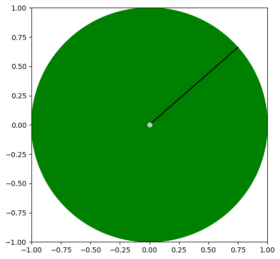

```python
import matplotlib.pyplot as plt # khai báo thư viện vẽ pyplot
import math

circle = plt.Circle((0, 0), 1, color='g') # tạo đối tượng vòng tròn

fig, ax = plt.subplots(figsize=(6, 6)) # lấy figure và vùng vẽ

plt.plot(0, 0, 'o', color=(0.9, 0.9, 1.0), alpha=0.8) # vẽ điểm tại tâm (0,0)
ax.add_patch(circle) # thêm vòng tròn vào vùng vẽ

x = 0.75; y = math.sqrt(1 - (x ** 2)) # (x = 0.75, y = căn bậc 2 của 1 - x^2)
plt.arrow(0, 0, x, y)

plt.xlim(-1, 1) # giới hạn trục x
plt.ylim(-1, 1) # giới hạn trục y

plt.savefig('pi.png') # lưu đồ thị xuống tập tin
plt.show()            # hiển thị đồ thị
```

```python
import numpy as np

def calc_pi_monte_carlo(n=100):
    # Sinh ngẫu nhiên n điểm (x, y) trong [-1, 1] x [-1, 1]
    x = np.random.uniform(-1, 1, n)
    y = np.random.uniform(-1, 1, n)

    # Đếm số điểm nằm trong đường tròn: x^2 + y^2 <= 1
    inside = np.sum(x**2 + y**2 <= 1)

    # Công thức Monte Carlo: pi ≈ 4 * (số điểm trong / tổng số điểm)
    pi_est = 4 * inside / n
    return pi_est
```

```python
import math

print("epsilon(n=100): ", calc_pi_monte_carlo(n = 100) - math.pi)
print("epsilon(n=100): ", calc_pi_monte_carlo(n = 100) - math.pi)
print("epsilon(n=10000): ", calc_pi_monte_carlo(n = 10000) - math.pi)
print("epsilon(n=10000): ", calc_pi_monte_carlo(n = 10000) - math.pi)
print("epsilon(n=1000000): ", calc_pi_monte_carlo(n = 1000000) - math.pi)
print("epsilon(n=1000000): ", calc_pi_monte_carlo(n = 1000000) - math.pi)
```

```
epsilon(n=100):  0.0984073464102071
epsilon(n=100):  0.018407346410207026
epsilon(n=10000):  -0.04919265358979308
epsilon(n=10000):  -0.04879265358979312
epsilon(n=1000000):  -0.0005286535897930378
epsilon(n=1000000):  0.00018734641020667908
```